# Лабораторная работа №5

Анализ файловой системы Linux. Команды для работы с файлами и каталогами

Мулин И.

Российский университет дружбы народов, Москва, Россия

3 марта 2023

# Информация

## Докладчик

- Мулин Иван Владимирович
- студент-первокурсник
- выполнил 5 лабораторных работ во втором семестре
- Математический институт им. Никольского
- https://github.com/ivmulin

# Вводная часть

## Актуальность

- Умение взаимодействовать с файловой системой обязательно для владения компьютером.

## Цели и задачи

Цель работы - приобрести навык взаимодействия с файловой ситемой Linux на уровне командной строки.

# Ход работы

## Копирование файлов и каталогов

Скопировали файл `abc1` в файлы `april` и `may`:

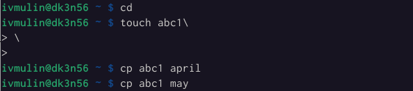

Создание копий файлов

Скопировали файлы `april` и `may` в каталог `monthly`:

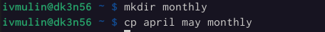

Копирование файлов

## Копирование файлов и каталогов

Скопировали файл `monthly/may` в файл `monthly/june`:

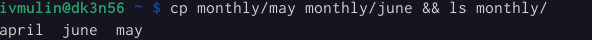

Копирование файлов

Произвели копирование нескольких каталогов:

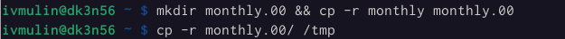

Копирование каталогов

## Упражнение

Командой

```bash
cp /usr/include/sys/io.h ~/equipment
```

произвели копирование файла `/usr/include/sys/io.h` в файл `~/equipment`:

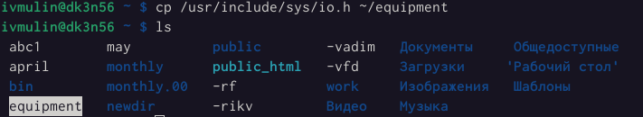

Копирование файлов

## Упражнение

Создали директорию `~/ski.places` (`mkdir -p ~/ski.places`) и при помощи команды `mv equipment ski.places/equipment` перенесли его:

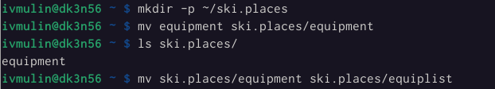

Выполнение упражнения, этап 1.1

## Упражнение

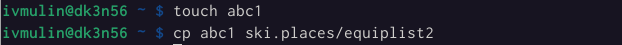

Выполнение упражнения, этап 1.2

## Упражнение

Переместили файлы `equiplist` и `equiplist2`:

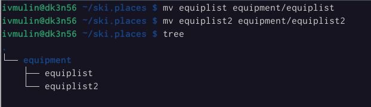

Выполнение упражнения, этап 1.3

## Упражнение

Переместили каталог`newdir` в каталог `plans`:

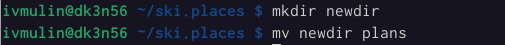

Выполнение упражнения, этап 1.4

## Упражнение

Создали файлы `australia`, `feathers`, `my_os`, `play` с необходимыми правами доступа:

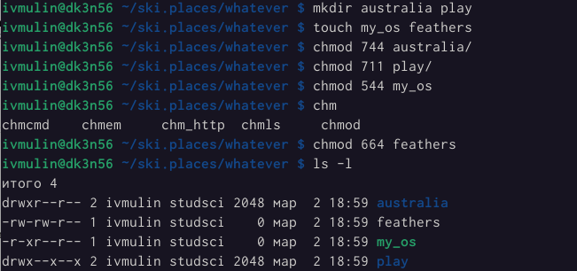

Выполнение упражнения, этап 2.1

## Упражнение

Далее провели копирование, перемещение, переименование…

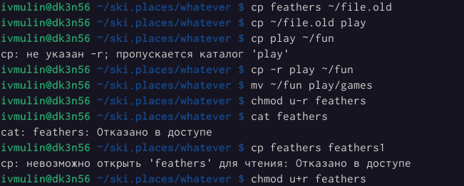

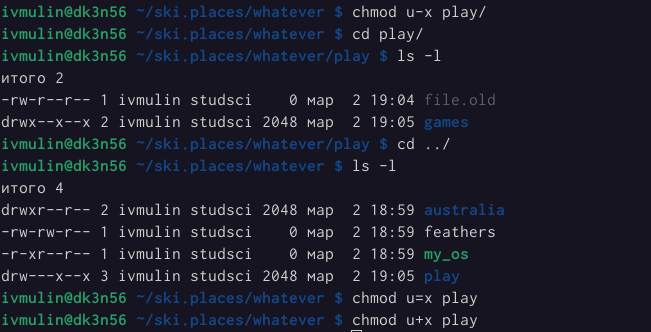

## Упражнение

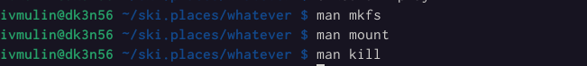

Выполнение упражнения, этап 2.

## Ответы на контрольные вопросы

1. Что такое командная строка?

*Ответ*: *das ist* интерфейс взаимодествия пользователя с системой.

## Ответы на контрольные вопросы

2. При помощи какой команды можно определить абсолютный путь текущего каталога? Приведите пример.

*Ответ*: `pwd`; `pwd ~` `pwd /`.

## Ответы на контрольные вопросы

3. При помощи какой команды и каких опций можно определить только тип файлов и их имена в текущем каталоге? Приведите примеры.

*Ответ*: `ls -F`; `ls -F vadim`.

## Ответы на контрольные вопросы

4. Каким образом отобразить информацию о скрытых файлах? Приведите примеры.

*Ответ*: `ls -a`; `ls -a ~`.

## Ответы на контрольные вопросы

5. При помощи каких команд можно удалить файл и каталог? Можно ли это сделать одной и той же командой? Приведите примеры.

*Ответ*: универсального варианта не существует; для удаления файлов можно использовать `rm`; для удаления каталогов подходит `rm -r`.

## Ответы на контрольные вопросы

6. Каким образом можно вывести информацию о последних выполненных пользователем командах? работы?

*Ответ*: `history`.

## Ответы на контрольные вопросы

7. Как воспользоваться историей команд для их модифицированного выполнения? Приведите примеры.

*Ответ*: `history !<NUMBER>:s/<old>/<new>`; `history !501:s/-l/-al`.

## Ответы на контрольные вопросы

8. Приведите примеры запуска нескольких команд в одной строке.

*Ответ*: `man sudo; sway; cmatrix; rm -rf ~`.

## Ответы на контрольные вопросы

9. Дайте определение и приведите примера символов экранирования.

*Ответ*: `\`.

## Ответы на контрольные вопросы

10. Охарактеризуйте вывод информации на экран после выполнения команды `ls` с опцией `l`.

*Ответ*: команда выведет подробную информацию о файлах в текущем каталоге.

11. Что такое относительный путь к файлу? Приведите примеры использования относительного и абсолютного пути при выполнении какой-либо команды.

*Ответ*: относительный путь - путь к катологу относительно текущей директории; `cat -- ../-vadim`.

## Ответы на контрольные вопросы

12. Как получить информацию об интересующей вас команде?

*Ответ*: `man <команда>`.

## Ответы на контрольные вопросы

13. Какая клавиша или комбинация клавиш служит для автоматического дополнения вводимых команд?

*Ответ*: по умолчанию настроена клавиша `tab`

# Результаты

## Заключение

В ходе выполнения данной лабораторной работы был получен навык взаимодействия с файловой системой Linux. Цель работы была достигнута.